# Rendu_titouan

```r
knitr::opts_chunk$set(echo = TRUE)
library(ggplot2)
library(factoextra)
library(dplyr)
Data=read.csv(file="./abalone/abalone.data")
Data = Data[1:100,2:9]
#head(Data)
Data = rename(Data, "Longueur"=`X0.455`, "Diamètre" = `X0.365`, "Hauteur" = `X0.095`, "Poids_Total"=`X0.514`, "Poids_Décortiqué"=`X0.2245`,"Poids_Viscères"=`X0.101`,"Poids_Coquille"=`X0.15`, "Anneaux"=`X15`)
head(Data)
```

```
##   Longueur Diamètre Hauteur Poids_Total Poids_Décortiqué Poids_Viscères
## 1    0.350    0.265   0.090      0.2255           0.0995         0.0485
## 2    0.530    0.420   0.135      0.6770           0.2565         0.1415
## 3    0.440    0.365   0.125      0.5160           0.2155         0.1140
## 4    0.330    0.255   0.080      0.2050           0.0895         0.0395
## 5    0.425    0.300   0.095      0.3515           0.1410         0.0775
## 6    0.530    0.415   0.150      0.7775           0.2370         0.1415
##   Poids_Coquille Anneaux
## 1          0.070       7
## 2          0.210       9
## 3          0.155      10
## 4          0.055       7
## 5          0.120       8
## 6          0.330      20
```

# Question 1

On centre dans un premier temps les variables de notre jeu de données. Pour cela, on commence par calculer les moyennes de chaque colonne, que l’on met dans un vecteur ligne, on répète cette ligne n fois pour obtenir une matrice de la même taille que notre jeu de données, et on soustrait cette matrice à notre jeu de données initial.

```r
moyennes = colMeans(Data)
n = nrow(Data)
p = ncol(Data)
moyennes = matrix(rep(moyennes, each=n))
Data_centre = Data - moyennes
head(Data_centre)
```

```
##   Longueur Diamètre Hauteur Poids_Total Poids_Décortiqué Poids_Viscères
## 1 -0.15305  -0.1288 -0.0413    -0.50182         -0.19025       -0.11183
## 2  0.02695   0.0262  0.0037    -0.05032         -0.03325       -0.01883
## 3 -0.06305  -0.0288 -0.0063    -0.21132         -0.07425       -0.04633
## 4 -0.17305  -0.1388 -0.0513    -0.52232         -0.20025       -0.12083
## 5 -0.07805  -0.0938 -0.0363    -0.37582         -0.14875       -0.08283
## 6  0.02695   0.0212  0.0187     0.05018         -0.05275       -0.01883
##   Poids_Coquille Anneaux
## 1       -0.16012   -3.58
## 2       -0.02012   -1.58
## 3       -0.07512   -0.58
## 4       -0.17512   -3.58
## 5       -0.11012   -2.58
## 6        0.09988    9.42
```

# Question 2

On cherche ici à réduire notre data set, pour cela on calcule l’écart type des données de chaque colonne (argument 2), en appliquant la fonction sd à chaque colonne de notre jeu de données. On répète ensuite cette ligne n fois pour obtenir une matrice de la même taille que notre jeu de données, et on divise notre jeu de données initial par cette matrice.

```r
ecart_type = apply(Data_centre, 2, sd)
ecart_type = matrix(rep(ecart_type, each=n))
Data_centre_reduit = Data_centre/ecart_type
head(Data_centre_reduit)
```

```
##     Longueur   Diamètre    Hauteur Poids_Total Poids_Décortiqué Poids_Viscères
## 1 -1.4570720 -1.4797441 -1.2166369  -1.2539831       -1.2472569     -1.2425915
## 2  0.2565703  0.3010038  0.1089965  -0.1257431       -0.2179831     -0.2092283
## 3 -0.6002508 -0.3308745 -0.1855887  -0.5280613       -0.4867744     -0.5147927
## 4 -1.6474767 -1.5946311 -1.5112221  -1.3052099       -1.3128157     -1.3425944
## 5 -0.7430544 -1.0776397 -1.0693443  -0.9391254       -0.9751877     -0.9203600
## 6  0.2565703  0.2435604  0.5508743   0.1253933       -0.3458229     -0.2092283
##   Poids_Coquille    Anneaux
## 1     -1.2091822 -1.0081629
## 2     -0.1519407 -0.4449434
## 3     -0.5672856 -0.1633337
## 4     -1.3224581 -1.0081629
## 5     -0.8315960 -0.7265531
## 6      0.7542663  2.6527638
```

les données sont alors de l’ordre de grandeur de 1 (entre -2 et 2 environ)

# Question 3

On stocke ensuite la matrice de covariance normé dans hatSigma

```r
hatSigma <- cov(Data_centre_reduit)
hatSigma
```

```
##                   Longueur  Diamètre   Hauteur Poids_Total Poids_Décortiqué
## Longueur         1.0000000 0.9872936 0.9258558   0.9224579        0.9161325
## Diamètre         0.9872936 1.0000000 0.9362003   0.9399541        0.9279551
## Hauteur          0.9258558 0.9362003 1.0000000   0.9084448        0.8803453
## Poids_Total      0.9224579 0.9399541 0.9084448   1.0000000        0.9692632
## Poids_Décortiqué 0.9161325 0.9279551 0.8803453   0.9692632        1.0000000
## Poids_Viscères   0.8936023 0.9001539 0.8863588   0.9355658        0.9515333
## Poids_Coquille   0.8758735 0.8975438 0.8790295   0.9603543        0.8796758
## Anneaux          0.7159627 0.7182953 0.7000823   0.7411373        0.7068338
##                  Poids_Viscères Poids_Coquille   Anneaux
## Longueur              0.8936023      0.8758735 0.7159627
## Diamètre              0.9001539      0.8975438 0.7182953
## Hauteur               0.8863588      0.8790295 0.7000823
## Poids_Total           0.9355658      0.9603543 0.7411373
## Poids_Décortiqué      0.9515333      0.8796758 0.7068338
## Poids_Viscères        1.0000000      0.8351496 0.6577045
## Poids_Coquille        0.8351496      1.0000000 0.7569556
## Anneaux               0.6577045      0.7569556 1.0000000
```

# Question 4

On diagonalises la matrice

```r
eigen_hatSigma <- eigen(hatSigma)
eigen_hatSigma$values    # Valeurs propres
```

```
## [1] 7.076876406 0.435328067 0.180050066 0.161642005 0.094374764 0.036070543
## [7] 0.010864343 0.004793806
```

```r
eigen_hatSigma$vectors   # Vecteurs propres
```

```
##           [,1]        [,2]        [,3]        [,4]        [,5]        [,6]
## [1,] 0.3627168 -0.12277760  0.41775891  0.21409616 -0.43269576 -0.20416086
## [2,] 0.3662748 -0.12621440  0.36386408  0.09899002 -0.35463565 -0.04406468
## [3,] 0.3565726 -0.12019210  0.46462000  0.03504811  0.73867827  0.30395057
## [4,] 0.3695732 -0.06467148 -0.28038214 -0.29027419 -0.04964468  0.09017463
## [5,] 0.3625005 -0.16174489 -0.43255303  0.14913764 -0.21424589  0.67328380
## [6,] 0.3541017 -0.27113924 -0.45487500  0.36962359  0.30256809 -0.59008548
## [7,] 0.3544739  0.11426547 -0.03165606 -0.79473665  0.00297659 -0.23270721
## [8,] 0.2968240  0.91522268 -0.05982507  0.26154607  0.03794924 -0.01395126
##             [,7]        [,8]
## [1,]  0.63362997 -0.05107141
## [2,] -0.76033466  0.04358536
## [3,]  0.05573132 -0.01312141
## [4,] -0.01273690 -0.82801069
## [5,]  0.09505427  0.35332720
## [6,] -0.05389864  0.12210347
## [7,]  0.06889179  0.41203835
## [8,] -0.02120392 -0.01389927
```

# Question 5

On sait que l’inertie totale de données centrée réduite est égale à la somme des valeurs propres de la matrice de covariance normée. Et cela vaut le nombre de variables, soit, ici, 8.

On calcule alors de 2 manière:  
- D’abord avec la formule de référence : Calculer la moyenne des carrés des observations pour chaque variable.  
- Ensuite en sommant les valeurs propres de la matrice de covariance normée.

```r
#Avec la formule
inertie_total1 <- sum(apply(Data_centre_reduit, 2, function(x) sum(x^2))) / (n - 1)
#Avec les valeurs propres
inertie_total2 <- sum(eigen_hatSigma$values)

inertie_total1
```

```
## [1] 8
```

```r
inertie_total2
```

```
## [1] 8
```

On trouve bien comme attendu 8 dans les deux cas

# Question 6

On trace, en fonction de i (la position dans le vecteur), le pourcentage de l’inertie expliqué par les i premières valeurs propres ainsi que celui expliqué par la i-ème valeur propre.

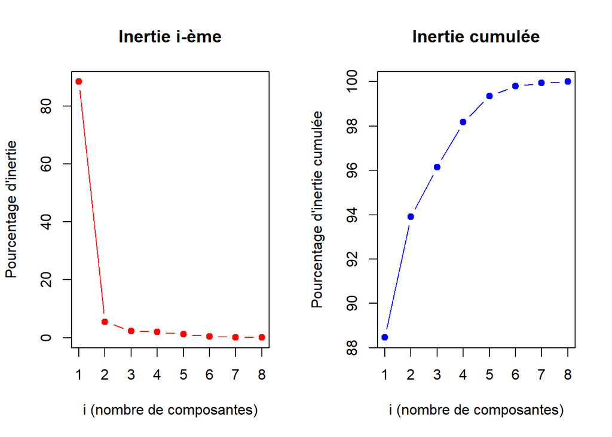

```r
pourcentages <- eigen_hatSigma$values / inertie_total1 * 100
pourcentage_cumule <- cumsum(pourcentages)

#On définit la fenêtre pour avoir 2 graphiques
par(mfrow = c(1, 2))

# Graphe 1 : inertie de la i-ème composante
plot(1:length(pourcentages), pourcentages, type="b", pch=19, col="red",
     xlab="i (nombre de composantes)", ylab="Pourcentage d'inertie",
     main="Inertie i-ème")

# Graphe 2 : inertie cumulée
plot(1:length(pourcentages), pourcentage_cumule, type="b", pch=19, col="blue",
     xlab="i (nombre de composantes)", ylab="Pourcentage d'inertie cumulée",
     main="Inertie cumulée")
```

# Question 7

On réalise une analyse en composantes principales (ACP) sur le jeu de données préalablement centré et réduit. On trace la projection des individus sur le plan factoriel défini par les deux premières composantes (axes 1 et 2), en affichant les noms des individus et en appliquant la fonction de repulsion pour éviter le chevauchement des étiquettes.  
On identifie également les individus les plus représentatifs des axes 1 et 2 en calculant les valeurs absolues maximales des scores des individus sur ces axes.

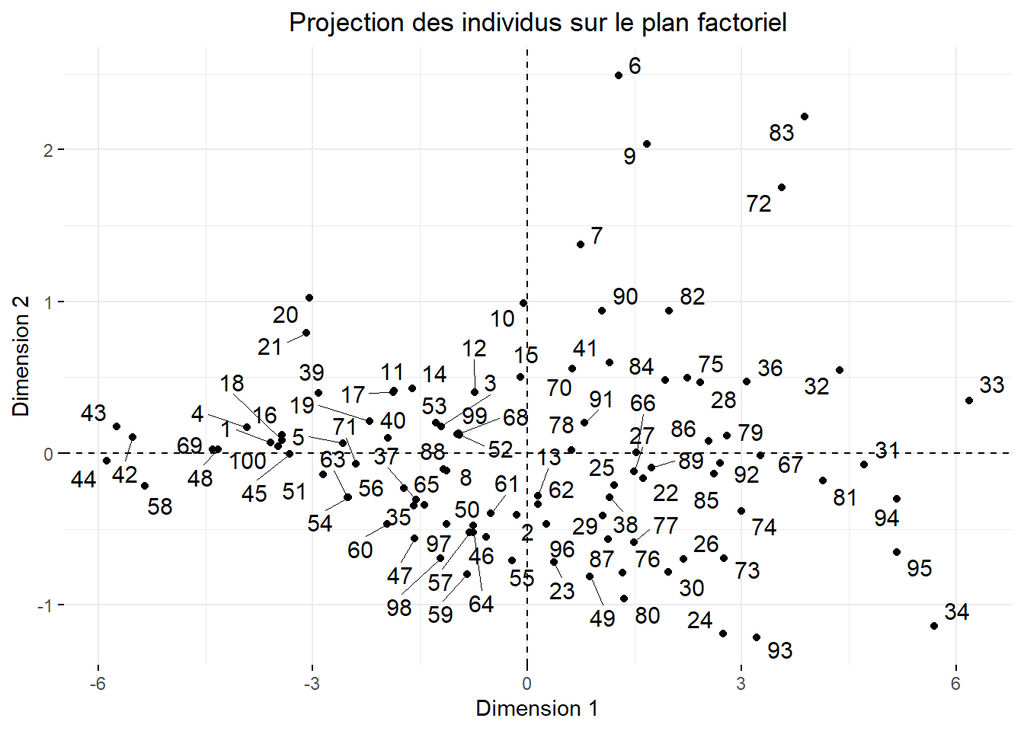

```r
acp_resultat <- prcomp(Data_centre_reduit, scale = TRUE) #contient scores des individus sur les différentes composantes principales

# Tracé du plan factoriel (Axes 1 et 2)
fviz_pca_ind(acp_resultat, axes = c(1,2),
             label = "ind",
             repel = TRUE,
             title = "Projection des individus sur le plan factoriel (Axes 1 et 2)")+
  labs(title = "Projection des individus sur le plan factoriel", x = "Dimension 1", y = "Dimension 2") +
  theme(plot.title = element_text(hjust = 0.5))
```

```r
# Identifier les individus les plus représentatifs des axes 1 et 2
coord_individus <- acp_resultat$x
ind_max_axe1 <- rownames(coord_individus)[which.max(abs(coord_individus[,1]))]
ind_max_axe2 <- rownames(coord_individus)[which.max(abs(coord_individus[,2]))]

# Affichage des résultats
cat("Individu le plus représentatif de l'axe 1 :", ind_max_axe1, "\n")
```

```
## Individu le plus représentatif de l'axe 1 : 33
```

```r
cat("Individu le plus représentatif de l'axe 2 :", ind_max_axe2, "\n")
```

```
## Individu le plus représentatif de l'axe 2 : 6
```

# Question 8

On produit un graphique du cercle des corrélations issu de l’analyse en composantes principales.  
On extrait ensuite les coefficients de chargement associés aux axes principaux pour repérer, parmi toutes les variables, celles qui influencent le plus le premier et le deuxième axe.  
Enfin, on examine le jeu de données standardisé pour identifier l’observation présentant la valeur la plus extrême pour chacune de ces variables déterminantes, ce qui permet d’associer les variables les plus contributives aux individus qui les illustrent le mieux.

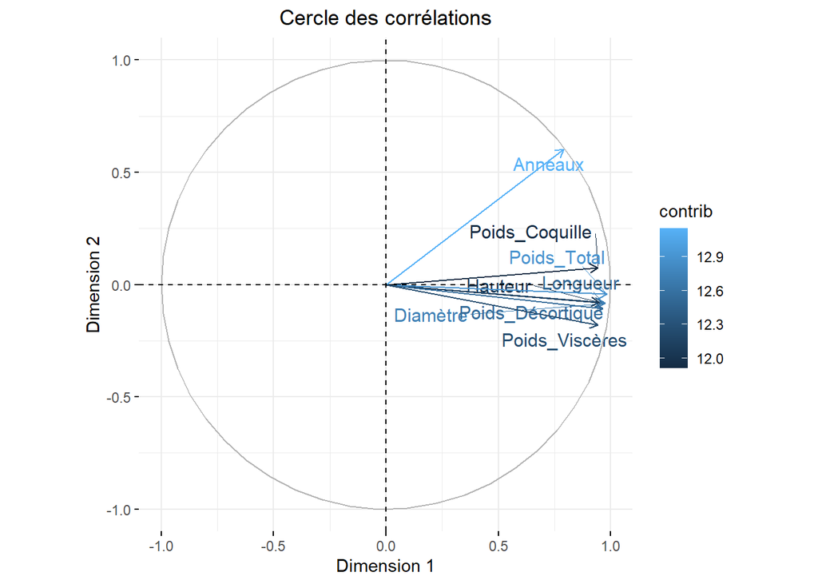

```r
# Représentation du cercle des corrélations pour les variables
fviz_pca_var(acp_resultat, repel = TRUE, col.var = "contrib") +
  labs(title = "Cercle des corrélations", x = "Dimension 1", y = "Dimension 2") +
  theme(plot.title = element_text(hjust = 0.5))
```

```r
# Extraction des chargements (loadings) issus de l'ACP
loadings <- acp_resultat$rotation

# Identification des variables les plus contributives pour les axes 1 et 2
var_PC1 <- names(which.max(abs(loadings[,1])))
var_PC2 <- names(which.max(abs(loadings[,2])))
cat("Variable la plus contributive pour PC1 :", var_PC1, "\n")
```

```
## Variable la plus contributive pour PC1 : Poids_Total
```

```r
cat("Variable la plus contributive pour PC2 :", var_PC2, "\n")
```

```
## Variable la plus contributive pour PC2 : Anneaux
```

```r
# Récupération des individus extrêmes pour ces variables à partir du jeu de données standardisé
ind_ext_PC1 <- which.max(abs(Data_centre_reduit[, var_PC1]))
ind_ext_PC2 <- which.max(abs(Data_centre_reduit[, var_PC2]))
cat("Individu extrême pour", var_PC1, ":", ind_ext_PC1, "\n")
```

```
## Individu extrême pour Poids_Total : 33
```

```r
cat("Individu extrême pour", var_PC2, ":", ind_ext_PC2, "\n")
```

```
## Individu extrême pour Anneaux : 83
```

# Question 9